# Illustrative case study 1

Thomas Debray

This report was generated on 23 september, 2022

# Original data sources

Previously, four RCTs of relapsing-remitting multiple sclerosis (RRMS) were combined in an integrated clinical trial database. This database includes patient-level data from the following trials:

- The ADVANCE trial includes 499 patients who received placebo every 2 weeks for 48 weeks followed by 125 $\mu$g peginterferon beta-1a subcutaneously every 2 or 4 weeks for 48 weeks (https://www.clinicaltrials.gov/ct2/show/NCT00906399)
- The DEFINE trial includes 408 patients who received two placebo capsules orally three times daily (https://www.clinicaltrials.gov/ct2/show/NCT00420212)
- The CONFIRM trial includes 363 patients who received two placebo capsules orally three times daily (https://www.clinicaltrials.gov/ct2/show/NCT00451451)
- The AFFIRM trial includes 312 patients who received placebo, intravenous infusion, every 4 weeks, for up to 116 weeks. (https://www.clinicaltrials.gov/ct2/show/NCT00027300)

We here consider the following baseline covariates (some of which were imputed):

Baseline characteristics of the Placebo patients in the original trials.

|  | AFFIRM (N=312) | ADVANCE (N=499) | DEFINE (N=408) | CONFIRM (N=363) |
| --- | --- | --- | --- | --- |
| Sex |  |  |  |  |
| Male | 104 (33.3%) | 141 (28.3%) | 102 (25.0%) | 112 (30.9%) |
| Female | 208 (66.7%) | 358 (71.7%) | 306 (75.0%) | 251 (69.1%) |
| Age (years) |  |  |  |  |
| Mean (SD) | 36.7 (7.83) | 36.3 (9.74) | 38.5 (9.14) | 36.9 (9.24) |
| Median [Min, Max] | 37.0 [19.0, 50.0] | 37.0 [18.0, 61.0] | 39.0 [18.0, 56.0] | 37.0 [18.0, 56.0] |
| Ethnicity |  |  |  |  |
| White | 293 (93.9%) | 413 (82.8%) | 318 (77.9%) | 305 (84.0%) |
| Non-white | 19 (6.1%) | 86 (17.2%) | 90 (22.1%) | 58 (16.0%) |
| Weight (kg) |  |  |  |  |
| Mean (SD) | 72.3 (16.0) | 69.1 (16.2) | 71.3 (17.1) | 72.7 (16.9) |
| Median [Min, Max] | 70.7 [39.5, 145] | 66.0 [42.0, 139] | 68.4 [37.0, 138] | 70.0 [43.0, 152] |
| Time since first multiple sclerosis symptoms (years) |  |  |  |  |
| Mean (SD) | 7.72 (6.67) | 6.35 (6.29) | 8.53 (6.84) | 7.65 (5.98) |
| Median [Min, Max] | 6.00 [0, 33.0] | 4.00 [0, 40.0] | 7.00 [0, 32.0] | 6.00 [0, 33.0] |
| Time since multiple sclerosis diagnosis (years) |  |  |  |  |
| Mean (SD) | 4.36 (4.78) | 3.54 (4.63) | 5.79 (5.78) | 4.81 (5.01) |
| Median [Min, Max] | 2.00 [0, 23.0] | 2.00 [0, 40.0] | 4.00 [0, 31.0] | 4.00 [0, 33.0] |
| Expanded Disability Status Scale |  |  |  |  |
| Mean (SD) | 2.30 (1.19) | 2.44 (1.18) | 2.48 (1.24) | 2.59 (1.17) |
| Median [Min, Max] | 2.00 [0, 6.00] | 2.00 [0, 5.00] | 2.50 [0, 6.00] | 2.50 [0, 5.00] |
| 9 Hole Peg Test Average Score |  |  |  |  |
| Mean (SD) | 21.3 (6.25) | 23.7 (13.1) | 23.8 (17.4) | 23.4 (12.7) |
| Median [Min, Max] | 20.0 [11.4, 64.4] | 21.6 [8.93, 268] | 20.4 [8.88, 245] | 21.3 [11.2, 194] |
| SF-36 mental component score |  |  |  |  |
| Mean (SD) | 47.0 (10.4) | 47.1 (10.3) | 45.7 (11.1) | 44.7 (10.8) |
| Median [Min, Max] | 48.9 [13.6, 65.8] | 47.5 [13.2, 68.6] | 48.0 [15.8, 65.9] | 46.1 [16.8, 70.3] |
| SF-36 physical component score |  |  |  |  |
| Mean (SD) | 44.2 (9.54) | 43.8 (10.3) | 43.2 (10.2) | 43.0 (9.84) |
| Median [Min, Max] | 45.3 [20.0, 65.9] | 44.5 [12.1, 62.9] | 44.1 [18.3, 66.8] | 42.7 [19.2, 63.4] |
| PASAT 3 |  |  |  |  |
| Mean (SD) | 50.9 (10.4) | 46.9 (11.7) | 48.0 (11.4) | 47.8 (11.6) |
| Median [Min, Max] | 55.0 [0, 60.0] | 50.0 [6.00, 60.0] | 52.0 [1.00, 60.0] | 51.0 [1.00, 60.0] |
| Timed 25 Foot Walk |  |  |  |  |
| Mean (SD) | 5.27 (1.79) | 7.94 (7.82) | 8.16 (12.9) | 6.62 (4.56) |
| Median [Min, Max] | 4.95 [2.60, 18.2] | 5.90 [3.10, 95.5] | 5.45 [3.00, 158] | 5.50 [2.60, 49.4] |
| VFT 2.5% |  |  |  |  |
| Mean (SD) | 34.1 (11.2) | 31.3 (12.5) | 32.7 (12.5) | 31.7 (11.6) |
| Median [Min, Max] | 35.5 [0, 57.0] | 34.0 [0, 56.0] | 35.0 [0, 57.0] | 34.0 [0, 55.0] |
| No. of Relapses within the previous 12 months |  |  |  |  |
| Mean (SD) | 1.50 (0.765) | 1.55 (0.670) | 1.30 (0.668) | 1.35 (0.802) |
| Median [Min, Max] | 1.00 [0, 5.00] | 1.00 [1.00, 4.00] | 1.00 [0, 4.00] | 1.00 [0, 8.00] |
| No. of Relapses within the previous 3 years |  |  |  |  |
| Mean (SD) | 2.65 (1.46) | 2.59 (1.00) | 2.55 (1.56) | 2.49 (1.49) |
| Median [Min, Max] | 2.00 [1.00, 14.0] | 2.00 [1.00, 9.00] | 2.00 [0, 12.0] | 2.00 [0, 10.0] |
| No. of months Since Recent Pre-Study Relapse |  |  |  |  |
| Mean (SD) | 6.27 (3.04) | 4.84 (2.69) | 6.65 (7.27) | 6.52 (5.72) |
| Median [Min, Max] | 6.00 [1.00, 13.0] | 4.00 [1.00, 13.0] | 5.00 [1.00, 119] | 5.00 [1.00, 64.0] |
| Brain Volume Z-Score |  |  |  |  |
| Mean (SD) | -0.0139 (0.986) | 0.0271 (1.05) | -0.0341 (1.01) | -0.0861 (1.01) |
| Median [Min, Max] | 0.0774 [-4.67, 2.20] | 0.0846 [-3.09, 2.86] | 0.0516 [-3.79, 2.16] | -0.116 [-3.79, 2.52] |
| Number of Gd+ lesions |  |  |  |  |
| Mean (SD) | 1.82 (4.13) | 1.59 (3.80) | 1.82 (4.41) | 2.31 (5.90) |
| Median [Min, Max] | 0 [0, 35.0] | 0 [0, 38.0] | 0 [0, 35.0] | 0 [0, 76.0] |
| Number of T1 weighted lesions |  |  |  |  |
| Mean (SD) | 30.1 (31.8) | 28.1 (29.1) | 32.8 (34.8) | 33.0 (32.0) |
| Median [Min, Max] | 20.0 [0, 240] | 20.0 [0, 212] | 22.0 [0, 240] | 24.0 [0, 240] |
| Number of T2 weighted lesions |  |  |  |  |
| Mean (SD) | 53.6 (38.2) | 50.6 (35.6) | 54.7 (41.7) | 57.6 (40.1) |
| Median [Min, Max] | 46.0 [2.00, 222] | 43.0 [1.00, 212] | 43.0 [0, 249] | 49.0 [0, 249] |

# Simulation of an observational study

We generated an artificial dataset with a predefined distribution of baseline EDSS for the control and active treatment group. To this purpose, we added 500 patients to the control group and 2000 patients to the active treatment group to the pooled placebo data and imputed their baseline and outcome data using multiple imputation. Subsequently, to mimic the presence of confounding, we omitted patients from the active comparator group according to the following baseline covariates: `T25FWABL` (Timed 25 Foot Walk), `SFPCSBL` (SF-36 physical component score), `SFMCSBL` (SF-36 mental component score), `GDLESBL` (Number of Gd+ lesions), `T1LESBL` (Number of T1 weighted lesions), `AGE` (age), `EDSSBL` (Expanded Disability Status Scale), `RLPS3YR` (No. of Relapses within the previous 3 years) and `SEX`. After imputation, the original trial data were omitted, resulting in a synthetic dataset of 1630 patients, with 500 patients receiving control and 1130 patients receiving ‘active’ placebo.

Baseline characteristics of the Placebo patients in the simulated observational study.

|  | Active (N=1130) | Control (N=500) | Overall (N=1630) |
| --- | --- | --- | --- |
| Sex |  |  |  |
| Male | 259 (22.9%) | 146 (29.2%) | 405 (24.8%) |
| Female | 871 (77.1%) | 354 (70.8%) | 1225 (75.2%) |
| Age (years) |  |  |  |
| Mean (SD) | 37.0 (9.42) | 35.4 (9.02) | 36.5 (9.32) |
| Median [Min, Max] | 37.0 [18.0, 61.0] | 35.0 [18.0, 61.0] | 37.0 [18.0, 61.0] |
| Ethnicity |  |  |  |
| White | 963 (85.2%) | 409 (81.8%) | 1372 (84.2%) |
| Non-white | 167 (14.8%) | 91 (18.2%) | 258 (15.8%) |
| Weight (kg) |  |  |  |
| Mean (SD) | 70.3 (16.2) | 71.0 (16.3) | 70.5 (16.2) |
| Median [Min, Max] | 68.0 [37.0, 145] | 68.0 [37.0, 140] | 68.0 [37.0, 145] |
| Time since first multiple sclerosis symptoms (years) |  |  |  |
| Mean (SD) | 7.95 (6.93) | 6.63 (6.08) | 7.54 (6.71) |
| Median [Min, Max] | 6.00 [0, 33.0] | 5.00 [0, 33.0] | 6.00 [0, 33.0] |
| Time since multiple sclerosis diagnosis (years) |  |  |  |
| Mean (SD) | 4.40 (5.10) | 3.57 (4.34) | 4.14 (4.90) |
| Median [Min, Max] | 3.00 [0, 31.0] | 2.00 [0, 31.0] | 2.00 [0, 31.0] |
| Expanded Disability Status Scale |  |  |  |
| Mean (SD) | 2.12 (1.11) | 2.46 (1.18) | 2.22 (1.15) |
| Median [Min, Max] | 2.00 [0, 6.00] | 2.50 [0, 6.00] | 2.00 [0, 6.00] |
| 9 Hole Peg Test Average Score |  |  |  |
| Mean (SD) | 21.2 (7.45) | 24.2 (15.4) | 22.1 (10.6) |
| Median [Min, Max] | 19.8 [9.00, 194] | 21.6 [8.93, 268] | 20.2 [8.93, 268] |
| SF-36 mental component score |  |  |  |
| Mean (SD) | 46.0 (10.5) | 46.1 (11.2) | 46.0 (10.7) |
| Median [Min, Max] | 47.5 [13.6, 67.2] | 47.7 [13.6, 68.6] | 47.6 [13.6, 68.6] |
| SF-36 physical component score |  |  |  |
| Mean (SD) | 44.8 (9.85) | 44.4 (9.97) | 44.7 (9.89) |
| Median [Min, Max] | 46.3 [16.7, 65.9] | 45.5 [12.1, 62.2] | 46.3 [12.1, 65.9] |
| PASAT 3 |  |  |  |
| Mean (SD) | 49.7 (10.6) | 46.5 (12.1) | 48.7 (11.2) |
| Median [Min, Max] | 54.0 [0, 60.0] | 50.0 [1.00, 60.0] | 53.0 [0, 60.0] |
| Timed 25 Foot Walk |  |  |  |
| Mean (SD) | 5.98 (4.10) | 7.63 (9.27) | 6.49 (6.21) |
| Median [Min, Max] | 5.10 [2.60, 71.3] | 5.85 [2.95, 158] | 5.20 [2.60, 158] |
| VFT 2.5% |  |  |  |
| Mean (SD) | 33.2 (11.7) | 31.3 (12.3) | 32.6 (11.9) |
| Median [Min, Max] | 35.0 [0, 57.0] | 34.0 [0, 57.0] | 35.0 [0, 57.0] |
| No. of Relapses within the previous 12 months |  |  |  |
| Mean (SD) | 1.30 (0.527) | 1.53 (0.747) | 1.37 (0.612) |
| Median [Min, Max] | 1.00 [0, 3.00] | 1.00 [0, 5.00] | 1.00 [0, 5.00] |
| No. of Relapses within the previous 3 years |  |  |  |
| Mean (SD) | 2.15 (0.874) | 2.51 (1.18) | 2.26 (0.993) |
| Median [Min, Max] | 2.00 [0, 7.00] | 2.00 [0, 9.00] | 2.00 [0, 9.00] |
| No. of months Since Recent Pre-Study Relapse |  |  |  |
| Mean (SD) | 6.13 (4.69) | 5.26 (3.59) | 5.86 (4.40) |
| Median [Min, Max] | 5.00 [1.00, 119] | 4.00 [1.00, 44.0] | 5.00 [1.00, 119] |
| Brain Volume Z-Score |  |  |  |
| Mean (SD) | 0.0982 (1.01) | 0.157 (1.07) | 0.116 (1.03) |
| Median [Min, Max] | 0.132 [-4.97, 3.33] | 0.150 [-4.74, 3.09] | 0.136 [-4.97, 3.33] |
| Number of Gd+ lesions |  |  |  |
| Mean (SD) | 0.481 (1.00) | 1.62 (3.05) | 0.831 (1.95) |
| Median [Min, Max] | 0 [0, 7.00] | 0 [0, 20.0] | 0 [0, 20.0] |
| Number of T1 weighted lesions |  |  |  |
| Mean (SD) | 23.5 (25.0) | 31.0 (31.0) | 25.8 (27.2) |
| Median [Min, Max] | 16.0 [0, 240] | 21.0 [0, 240] | 17.0 [0, 240] |
| Number of T2 weighted lesions |  |  |  |
| Mean (SD) | 47.3 (33.8) | 53.5 (37.6) | 49.2 (35.1) |
| Median [Min, Max] | 39.0 [0, 249] | 46.0 [0, 222] | 41.0 [0, 249] |

In the simulated observational study, patients receiving the ‘active’ placebo clearly differ from patients receiving the ‘control’ placebo.

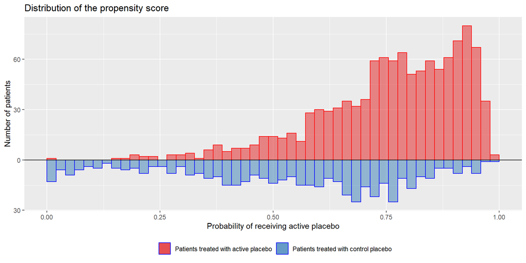

There is imbalance for several covariates:

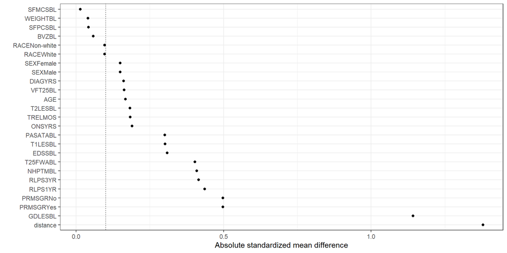

The distribution of the disease risk score is as follows:

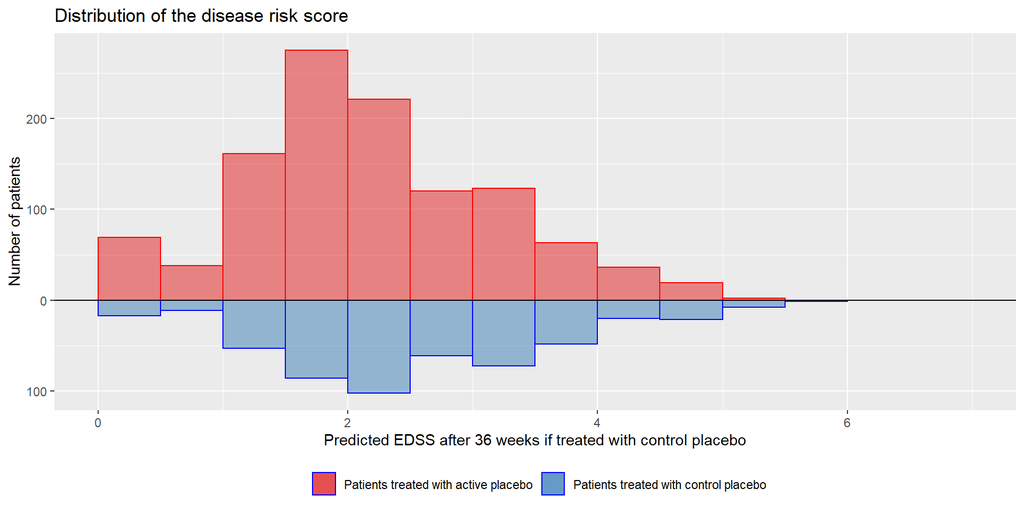

# Estimation of the treatment effect

We consider the Expanded Disability Status Scale (EDSS) measured 36 weeks after baseline as the primary outcome. The EDSS score is a scale that quantifies disability in 0.5 unit increments, and ranges from 0 (no disability) to 10 (death due to MS). Subsequently, we estimate the ATT in the simulated observation study using five approaches:

- Naive: A linear regression ignoring the potential presence of confounding and effect modification.
- DSR NNM: nearest neighbour matching using the disease risk score
- DSR OFM: optimal full matching using the disease risk score
- DSR IPW: inverse probability weighting using the disease risk score
- DSR TDW: target distribution weighting using the disease risk score

The disease risk score was calculated using linear regression in the control group, and includes the following baseline covariates as main effects: `AGE`, `SEX`, `RACE`, `WEIGHTBL`, `ONSYRS`, `DIAGYRS`, `PRMSGR`, `RLPS1YR`, `RLPS3YR`, `GDLESBL`, `T1LESBL`, `T2LESBL`, `NHPTMBL`, `PASATABL`, `T25FWABL`, `EDSSBL`, `TRELMOS`, `SFPCSBL`, `SFMCSBL`, `BVZBL` and `VFT25BL`.

# Results

The treatment effect estimates in this illustrative case study are as follows:

| Method | Reference | Estimate | SE | X95.CI | Time |
| --- | --- | --- | --- | --- | --- |
| naive | 0 | -0.33 | 0.07 | -0.46 ; -0.20 | 0.00 |
| DSR NNM | 0 | 0.02 | 0.08 | -0.14 ; 0.17 | 0.03 |
| DSR OFM | 0 | 0.07 | 0.06 | -0.06 ; 0.19 | 2.58 |
| DSR IPW | 0 | 0.06 | 0.06 | -0.05 ; 0.18 | 0.00 |
| DSR TDW | 0 | 0.04 | 0.06 | -0.08 ; 0.17 | 0.04 |

Finally, we apply bootstrapping to improve estimation of standard errors:

| Method | Reference | Estimate | SE | X95.CI | Time |
| --- | --- | --- | --- | --- | --- |
| naive | 0 | -0.43 | 0.07 | -0.57 ; -0.30 | 1.23 |
| DSR NNM | 0 | -0.01 | 0.08 | -0.12 ; 0.10 | 29.42 |
| DSR OFM | 0 | 0.01 | 0.07 | -0.11 ; 0.13 | 1897.12 |
| DSR IPW | 0 | 0.02 | 0.06 | -0.08 ; 0.13 | 5.86 |
| DSR TDW | 0 | 0.00 | 0.07 | -0.09 ; 0.10 | 4.02 |